# Homework 1

- Machine Learning Main Ideas
  - Question 1
  - Question 2
  - Question 3
  - Question 4
  - Question 5
- Exploratory Data Analysis
  - Question 1
  - Question 2
  - Question 3
  - Question 4
  - Question 5

## Machine Learning Main Ideas

### 1).

Define supervised and unsupervised learning. What are the difference(s) between them?

Supervised learning is a method of machine learning in which for each observation from our dataset, there is an associated response variable we are attempting to predict. In contrast, unsupervised learning is a machine learning method that once again uses observations, but has no associated response variable we are attempting to predict. Unsupervised learning is typically used to understand the relationships between our observations.

### 2).

Explain the difference between a regression model and a classification model, specifically in the context of machine learning.

Both regression and classification models are types of supervised machine learning methods in which we use observations to predict some response variable. In regression our response variable is a quantitative variable, or a numerical variable. Whereas in classification, our response variable is a qualitative variable, or a categorical variable. Both of these methods are attempting to do the same thing but with different types of responses.

### 3).

Name two commonly used metrics for regression ML problems. Name two commonly used metrics for classification ML problems.

**Regression**:

MSE = $\frac{1}{n}\sum^n_{i=1}(y_i-\hat{f}(x_i))^2$

The mean squared error measures how close our predicted responses are to the true value for that specific observation of our training data.

$E(y_0-\hat{f}(x_0))^2 = Var(\hat{f}(x_0)) + [Bias(\hat{f}(x_0))]^2 + Var(\epsilon)$

The expected test mean squared error measures the average test mean squared error we would find if we were to use many different large training sets to calculate different values of f.

**Classification**:

Error rate = $\frac{1}{n}\sum^n_{i=1}I(y_i \neq \hat{y}_i)$

The training error rate measures the proportion of observations that are given the wrong predictor class label.

Bayes error rate = $1-E[max_j Pr(Y=j|X))$

The bayes error rate gives us an error measurement based on the Bayes Classifier, which assigns the class for which $Pr(Y=j|X=x_0)$ is largest. This error rate is essentially the same as the irreducible error.

All the above equations and similar descriptions come from our textbook.

### 4).

As discussed, statistical models can be used for different purposes. These purposes can generally be classified into the following three categories. Provide a brief description of each.

- Descriptive models:
- Inferential models:
- Predictive models:

**Descriptive Models:**

These models are used to summarize or describe patterns found in data. They focus on understanding features of a dataset such as its distribution, averages, or relationships between variables. These models don't attempt to make predictions about future datapoints.

**Inferential Models:**

These models aim to make generalizations about a population based on a sample of data. They are able to help estimate parameters and test hypotheses to determine if the observed data can be generalized to a broader context.

**Predictive Models:**

These models focus primarily on predicting future outcomes or values based on historical data. They are able to use patterns learned from training data to predict future trends.

### 5).

A political candidate’s campaign has collected some detailed voter history data from their constituents. The campaign is interested in two questions:

- Given a voter’s profile/data, how likely is it that they will vote in favor of the candidate?
- How would a voter’s likelihood of support for the candidate change if they had personal contact with the candidate?

Classify each question as either predictive or inferential. Explain your reasoning for each.

1. This is a prective question because the goal is to forecast an outcome for a new observation based on existing voter data.
2. This an inferential question because it requires estimating how personal contact with a candidate influences voter behavior, which involves making inferences from the data rather than a prediction.

## Exploratory Data Analysis

```python
import pandas as pd
import numpy as np
import matplotlib.pyplot as plt
import seaborn as sns

mpg = pd.read_csv('mpg.csv')
```

### 1).

We are interested in highway miles per gallon, or the hwy variable. Create a histogram of this variable. Describe what you see/learn.

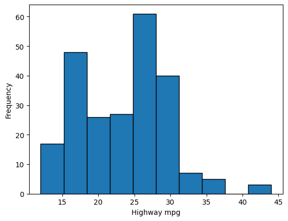

```python
plt.hist(mpg['hwy'], edgecolor='black')
plt.xlabel('Highway mpg')
plt.ylabel('Frequency')
plt.show()
```

We can see that there is a large amount of cars with ~15-18 highway mpg and ~25-27.5 highway mpg, with the latter being the largest group. There are a few cars with ~41-44 highway mpg. Once we start going past ~31 mpg there is a huge dropoff in the frequency as well. We can see that most cars have around 15-30 highway mpg.

### 2).

Create a scatterplot. Put hwy on the x-axis and cty on the y-axis. Describe what you notice. Is there a relationship between hwy and cty? What does this mean?

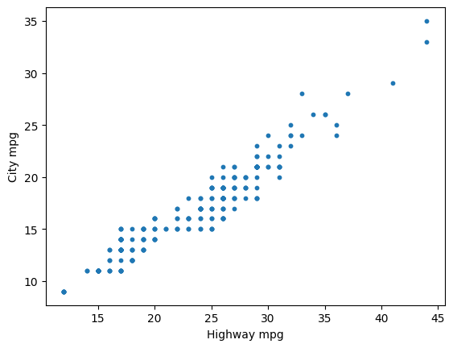

```python
mpg.plot.scatter(x='hwy', y='cty', s=10)
plt.xlabel('Highway mpg')
plt.ylabel('City mpg')
plt.show()
```

We can see there does appear to be a positive relationship between hwy and cty. It seems that as a car's highway mpg increases, so does its city mpg.

### 3).

Make a bar plot of manufacturer. Flip it so that the manufacturers are on the y-axis. Order the bars by height. Which manufacturer produced the most cars? Which produced the least?

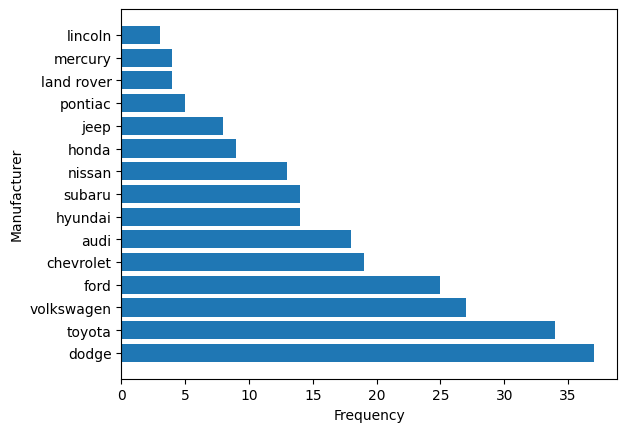

```python
frequencies = mpg['manufacturer'].value_counts()

plt.barh(frequencies.index, frequencies.values)
plt.xlabel('Frequency')
plt.ylabel('Manufacturer')
plt.show()
```

We can clearly see that dodge produced the most cars and lincoln produced the least.

### 4).

Make a box plot of hwy, grouped by cyl. Use geom_jitter() and the alpha argument to add points to the plot.

Describe what you see. Is there a relationship between hwy and cyl? What do you notice?

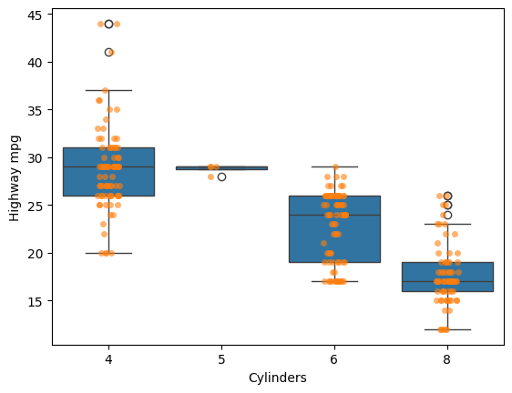

```python
sns.boxplot(x='cyl', y='hwy', data=mpg)
sns.stripplot(x='cyl', y='hwy', data=mpg, jitter=True, alpha=0.6)
plt.xlabel('Cylinders')
plt.ylabel('Highway mpg')
plt.show()
```

We can clearly see that as the number of cylinders increases, all statistics about a cars highway mpg seems to decrease. The range of values for the mpg for each cylinder type seems to stay fairly consistent, aside from cars with 5 cylinders likely because there isn't much data.

### 5).

Use the corrplot package to make a lower triangle correlation matrix of the mpg dataset. (Hint: You can find information on the package here.)

Which variables are positively or negatively correlated with which others? Do these relationships make sense to you? Are there any that surprise you?

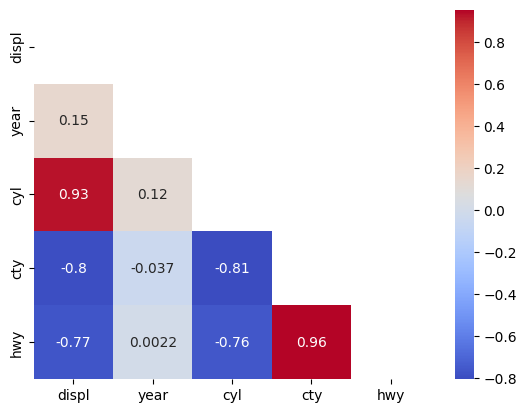

```python
corr = mpg.corr(numeric_only=True)
sns.heatmap(corr, mask = np.triu(np.ones_like(corr, dtype=bool)), annot=True,
            cmap='coolwarm')
```

We can see that cylinder and displacement have a strong positive correlation, as well as city mpg and highway mpg. Both of these makes sense because the amount of displacement a car has refers to the volume of the cylinders, so more cylinders results in more volume. Also if a car has a large highway mpg, it will also have a large city mpg. We can also see that displacement and city mpg, displacement and highway mpg, cylinders and highway mpg, and cylinders and city mpg have strong negative correlations. Once again, these make sense because cars with larger and stronger engines typically consume much more fuel than other cars.